# Data Analysis Using Statistical Packages: Miller et al. (AJPS 2016)

Sho Kuroda / 黒田翔

2024年3月 (Last update: 2024年3月)

# 1 Overview

[Miller, Saunders, and Farhart (AJPS 2016)](https://onlinelibrary.wiley.com/doi/full/10.1111/ajps.12234) [Open access]

Question. イデオロギーに動機付けられた陰謀論（例：保守派が好む陰謀論）を支持するのはどのような人々か？

この論文では政治的な要因に焦点を当てサーベイデータを用いた実証分析を行う．

## 1.1 Data

[Replication Data in Harvard Dataverse](https://dataverse.harvard.edu/dataset.xhtml?persistentId=doi:10.7910/DVN/O3A06T)

分析プログラム（Stata）とデータ（.dta）は Creative Commons CC0 ライセンスで配布されている．

授業の履修者は Moodle から Miller2016_MTurk.dta （元ファイル：MTurk.dta）をダウンロード可能．

注：MTurk (Mechanical Turk) はAmazonが提供するクラウドソーシングサービスで，オンライン調査（アンケート）などが可能．

```r
setwd("c://ws_stat")
library(tidyverse)
cons <- haven::read_dta("Miller2016_MTurk.dta")
# str(cons)
```

主な変数：

- 自認する立場
  - `Conservative`: dummy variable for self-identified as conservative
- 陰謀論をどの程度信じているか
  - `conspiracy1`: Conspiracy: Obama was not born in the U.S.
  - `conspiracy3`: Conspiracy: Government knew about 9/11 prior to attacks
  - `con_index_rep2`: Conservative conspiracy index
  - `con_index_dem4`: Liberal conspiracy index
  - `negdemindex`: -1 × (Liberal conspiracy index)
- 回答者の知識・態度
  - `polknow_alt`: political knowledge index （例：ロシアの大統領の名前を正答できるか）
  - `trust_comb`: trust index （連邦政府やメディアが正しいことを行っていると信頼するか）

```r
summary(cons[, c("con_index_rep2", "polknow_alt", "trust_comb")])
```

```
##  con_index_rep2     polknow_alt       trust_comb
##  Min.   :0.00000   Min.   :0.0000   Min.   :0.0000
##  1st Qu.:0.08333   1st Qu.:0.4286   1st Qu.:0.2500
##  Median :0.25000   Median :0.6429   Median :0.4167
##  Mean   :0.28333   Mean   :0.5995   Mean   :0.3857
##  3rd Qu.:0.41667   3rd Qu.:0.7857   3rd Qu.:0.5000
##  Max.   :1.00000   Max.   :1.0000   Max.   :1.0000
##  NA's   :93                         NA's   :136
```

```r
table(cons$Conservative)  # frequency distribution table
```

```
##
##    0    1
## 1514  689
```

```r
table(cons$conspiracy1)
```

```
##
##                 0 0.333333343267441 0.666666686534882                 1
##              1797               670               357               158
```

```r
table(cons$conspiracy3)
```

```
##
##                 0 0.333333343267441 0.666666686534882                 1
##               622              1080               892               363
```

```r
summary(cons$age)
```

```
##    Min. 1st Qu.  Median    Mean 3rd Qu.    Max.    NA's
##   18.00   25.00   30.00   34.29   41.00   81.00     261
```

```r
table(cons$female)
```

```
##
##    0    1
## 1190 1633
```

注：Stata では `.` が欠損値を表すが，`read_dta` で読み込むと `NA` として認識される．

.dta ファイルに含まれていた変数のラベルは以下のように確認できる（ただし，ラベルが長すぎてRに読み込む際に途中で切れてしまっている）．

```r
attr(cons$Conservative, "label")
```

```
## [1] "Conservative Dummy without Moderates: Recode of ideo7"
```

```r
attr(cons$con_index_rep2, "label")
```

```
## [1] "Conservative Conspiracy Index (Avg of conspiracy1 conspiracy2 conspiracy7 conspi"
```

諸事情により（交互作用項の効果を描画するため）ラベルを短くしておく．

```r
attr(cons$Conservative, "label") <- "Self-identified Ideology"
attr(cons$con_index_rep2, "label") <- "Conservative Conspiracy Index"
attr(cons$con_index_dem4, "label") <- "Liberal Conspiracy Index"
```

# 2 Hypothesis 1 / 仮説1：保守派はリベラル派よりもイデオロギー的に一貫した陰謀を支持する

## 2.1 Descriptive evidence (Table 1)

保守派はリベラル派よりも「保守層が好む陰謀論」を支持し，その逆にリベラル派は保守派よりも「リベラル層が好む陰謀論」を支持する．

ポイントはその程度の差． 保守派とリベラル派の「保守派が好む陰謀論」の支持率の差が大きく，保守派とリベラル派の「リベラル派が好む陰謀論」の支持率の差が小さいなら，仮説１は支持される．

### 2.1.1 Descriptive statistics

`conservative_conspiracy`: 「保守層が好む陰謀論」の支持率の平均 ― 保守派 vs. リベラル派

`liberal_conspiracy`: 「リベラル層が好む陰謀論」の支持率の平均 ― 保守派 vs. リベラル派

```r
cons %>%
  group_by(Conservative) %>%
  summarise(conservative_conspiracy = mean(con_index_rep2, na.rm = TRUE),
            liberal_conspiracy = mean(con_index_dem4, na.rm = TRUE))
```

```
## # A tibble: 3 × 3
##   Conservative      conservative_conspiracy liberal_conspiracy
##   <dbl+lbl>                           <dbl>              <dbl>
## 1  0 [Liberal]                        0.188              0.500
## 2  1 [Conservative]                   0.447              0.334
## 3 NA                                  0.323              0.470
```

合成されたインデックスの差は，「保守派が好む陰謀論」では 0.19 - 0.45 = -0.26，「リベラル派が好む陰謀論」では 0.50 - 0.33 = 0.17 なので，仮説1とは整合している．

### 2.1.2 Test

Stata: `ttest conspiracy1, by(Conservative) level(95) unequal` etc.

保守派とリベラル派の「保守派が好む陰謀論」の支持率の差の検定．

```r
t.test(conspiracy1 ~ Conservative, data = cons)  # Obama
```

```
##
##  Welch Two Sample t-test
##
## data:  conspiracy1 by Conservative
## t = -22.968, df = 958.13, p-value < 2.2e-16
## alternative hypothesis: true difference in means between group 0 and group 1 is not equal to 0
## 95 percent confidence interval:
##  -0.3345162 -0.2818512
## sample estimates:
## mean in group 0 mean in group 1
##      0.09259259      0.40077633
```

```r
t.test(con_index_rep2 ~ Conservative, data = cons)  # index
```

```
##
##  Welch Two Sample t-test
##
## data:  con_index_rep2 by Conservative
## t = -29.458, df = 1109.9, p-value < 2.2e-16
## alternative hypothesis: true difference in means between group 0 and group 1 is not equal to 0
## 95 percent confidence interval:
##  -0.2767355 -0.2421732
## sample estimates:
## mean in group 0 mean in group 1
##       0.1877800       0.4472344
```

保守派とリベラル派の「リベラル派が好む陰謀論」の支持率の差の検定．

```r
t.test(conspiracy3 ~ Conservative, data = cons)  # 9/11
```

```
##
##  Welch Two Sample t-test
##
## data:  conspiracy3 by Conservative
## t = 0.84234, df = 1224.1, p-value = 0.3998
## alternative hypothesis: true difference in means between group 0 and group 1 is not equal to 0
## 95 percent confidence interval:
##  -0.01682104  0.04213250
## sample estimates:
## mean in group 0 mean in group 1
##       0.4337084       0.4210526
```

```r
t.test(con_index_dem4 ~ Conservative, data = cons)  # index
```

```
##
##  Welch Two Sample t-test
##
## data:  con_index_dem4 by Conservative
## t = 16.925, df = 1103.4, p-value < 2.2e-16
## alternative hypothesis: true difference in means between group 0 and group 1 is not equal to 0
## 95 percent confidence interval:
##  0.1467243 0.1852054
## sample estimates:
## mean in group 0 mean in group 1
##       0.4997430       0.3337781
```

## 2.2 Formal test: Regression (Table 2)

個人属性（年齢，性別，人種，所得，政治に関する知識，etc.）を制御したもとで，保守派かどうかが「保守派が好む陰謀論」に与える影響と，保守派かどうかが「リベラル派が好む陰謀論」に与える影響の大きさを比べる．

影響の大きさは回帰式の回帰係数として定量化する．

$$\mbox{Conservative conspiracy} =
\beta_0 + \beta_1 \mbox{Self-identified as conservative} + \beta_2
\mbox{Political knowledge} + \beta_3 \mbox{Trust} + \cdots$$

懸念：教育や所得など bad control となっている可能性のある変数がコントロールに含まれる．

Stata: `reg con_index_rep2 Conservative polknow_alt ...` etc.

```r
lm_cons <- lm(con_index_rep2 ~ Conservative + polknow_alt + trust_comb + extraversion + agreeableness + conscientiousness + emostab + openness + auth + efficacy + needcog_comb + needeval_comb_alt + ideo_extr + fed_power + religiosity + educ_alt + income + female + age_alt + latino + white, data = cons)
# summary(lm_cons)
lm_lib <- lm(con_index_dem4 ~ Conservative + polknow_alt + trust_comb + extraversion + agreeableness + conscientiousness + emostab + openness + auth + efficacy + needcog_comb + needeval_comb_alt + ideo_extr + fed_power + religiosity + educ_alt + income + female + age_alt + latino + white, data = cons)
# summary(lm_lib)
```

推定結果（一部の変数のみ）をまとめて表示する．

```r
# install.packages("modelsummary")  # run only the first time
library(modelsummary)
msummary(list(lm_cons, lm_lib), gof_omit = "AIC|BIC|Log.Lik.|F|RMSE",
         stars = TRUE, coef_omit = c(5:16, 21:22))
```

|  | (1) | (2) |
| --- | --- | --- |
| (Intercept) | 0.200*** | 0.721*** |
|  | (0.030) | (0.034) |
| Conservative | 0.208*** | -0.177*** |
|  | (0.009) | (0.010) |
| polknow_alt | -0.177*** | -0.120*** |
|  | (0.021) | (0.024) |
| trust_comb | -0.076** | -0.300*** |
|  | (0.027) | (0.030) |
| educ_alt | -0.054*** | -0.023 |
|  | (0.014) | (0.015) |
| income | 0.016 | -0.058*** |
|  | (0.013) | (0.014) |
| female | 0.013 | 0.003 |
|  | (0.008) | (0.009) |
| age_alt | 0.022 | 0.060** |
|  | (0.020) | (0.022) |
| Num.Obs. | 1951 | 1951 |
| R2 | 0.449 | 0.284 |
| R2 Adj. | 0.443 | 0.276 |

+ p < 0.1, * p < 0.05, ** p < 0.01, *** p < 0.001

`Conservative` ダミーの回帰係数は，「保守派が好む陰謀論」をアウトカムとした場合の方が大きい．

注：論文では Seemingly Unrelated Regression と呼ばれる分析手法を用いて `Conservative` ダミーの回帰係数の大きさを統計的に比較している．

# 3 Hypothesis 2 / 仮説2：知識が豊富なほどイデオロギー的に一貫した陰謀を支持する

イデオロギーと知識の交互作用項（交差項）を導入する．

$$\mbox{Conservative conspiracy} =
\beta_0 + \beta_1 \mbox{Self-identified as conservative} + \beta_2
\mbox{Political knowledge} \\ + \beta_3 \mbox{Self-identified as
conservative} \times \mbox{Political knowledge} + \beta_4 \mbox{Trust} +
\cdots$$

Stata: `reg con_index_rep2 i.Conservative##c.polknow_alt trust_comb ...` etc.

`w*z` で「w + z + w×z」が説明変数として加えられる．

`w:z` は「w×z」に対応する． つまり `w*z` と `w + z + w:z` は同じ．

```r
lm_cons_h2 <- lm(con_index_rep2 ~ Conservative + polknow_alt + Conservative:polknow_alt + trust_comb + extraversion + agreeableness + conscientiousness + emostab + openness + auth + efficacy + needcog_comb + needeval_comb_alt + ideo_extr + fed_power + religiosity + educ_alt + income + female + age_alt + latino + white, data = cons)
# summary(lm_cons_h2)
lm_lib_h2 <- lm(con_index_dem4 ~ Conservative + polknow_alt + Conservative:polknow_alt + trust_comb + extraversion + agreeableness + conscientiousness + emostab + openness + auth + efficacy + needcog_comb + needeval_comb_alt + ideo_extr + fed_power + religiosity + educ_alt + income + female + age_alt + latino + white, data = cons)
# summary(lm_lib_h2)
```

推定結果（一部の変数のみ）をまとめて表示する．

```r
msummary(list(lm_cons_h2, lm_lib_h2), gof_omit = "AIC|BIC|Log.Lik.|F|RMSE",
         stars = TRUE, coef_omit = c(5:16, 21:22))
```

|  | (1) | (2) |
| --- | --- | --- |
| (Intercept) | 0.292*** | 0.659*** |
|  | (0.031) | (0.035) |
| Conservative | -0.030 | -0.018 |
|  | (0.027) | (0.030) |
| polknow_alt | -0.296*** | -0.042 |
|  | (0.024) | (0.027) |
| trust_comb | -0.067* | -0.306*** |
|  | (0.027) | (0.030) |
| educ_alt | -0.057*** | -0.021 |
|  | (0.014) | (0.015) |
| income | 0.011 | -0.054*** |
|  | (0.013) | (0.014) |
| female | 0.017* | 0.001 |
|  | (0.008) | (0.009) |
| age_alt | 0.022 | 0.060** |
|  | (0.020) | (0.022) |
| Conservative × polknow_alt | 0.362*** | -0.241*** |
|  | (0.038) | (0.043) |
| Num.Obs. | 1951 | 1951 |
| R2 | 0.474 | 0.295 |
| R2 Adj. | 0.468 | 0.287 |

+ p < 0.1, * p < 0.05, ** p < 0.01, *** p < 0.001

知識によってイデオロギーの効果がどのように異なるかを可視化する（Figure 1）．

Stata: `marginsplot` ect.

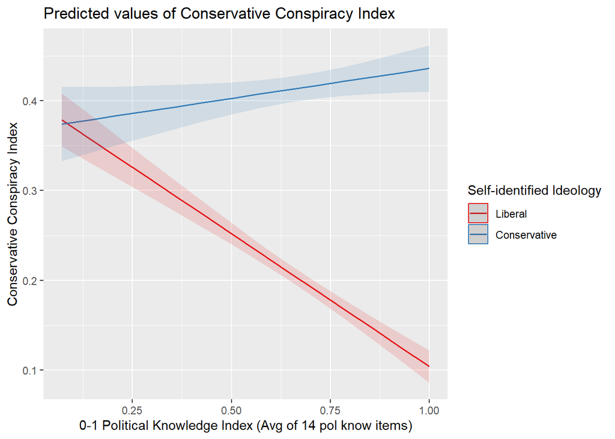

```r
# install.packages("sjPlot")
library(sjPlot)
plot_model(model = lm_cons_h2, type = "pred", terms = c("polknow_alt", "Conservative"), ci.lvl = 0.95)
```

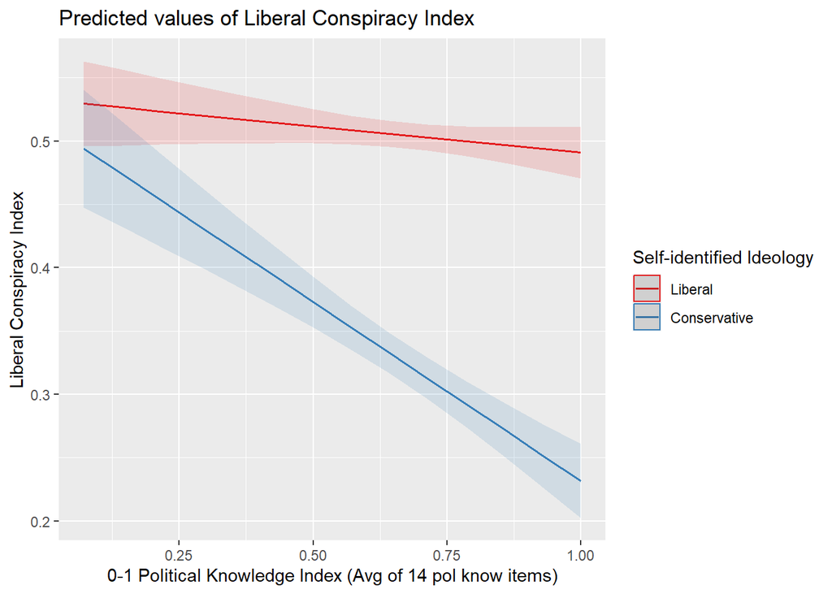

```r
plot_model(model = lm_lib_h2, type = "pred", terms = c("polknow_alt", "Conservative"), ci.lvl = 0.95)
```

知識が豊富なほどイデオロギーに一貫した陰謀論をより支持する現象は，保守層でのみ確認される．

注：論文のFigure 1とは信頼区間が僅かに異なる．

# 4 Hypothesis 3 / 仮説3：イデオロギーに一貫した知識の交互作用効果が信頼によって消える

本演習では省略するが，3要因の交互作用項を用いることで分析する．

Stata: `reg con_index_rep2 i.Conservative##c.trust_comb##c.polknow_alt ...` etc.

R:

```r
lm_cons_h3 <- lm(con_index_rep2 ~ Conservative*polknow_alt*trust_comb + extraversion + agreeableness + conscientiousness + emostab + openness + auth + efficacy + needcog_comb + needeval_comb_alt + ideo_extr + fed_power + religiosity + educ_alt + income + female + age_alt + latino + white, data = cons)
summary(lm_cons_h3)
```

.